# IODS course project

Himanshu Chheda

# Introduction to Open Data Science

### Author: Himanshu Chheda

*This course is designed to learn* **open data science** *, where* **open** *means publishing the code which eventually leads to reproducibility.* **Data science** *means number crunching to analyze and identify inherent patters in the data. The link to my coding capabilities attached below:*

[Github: himanshuchheda](https://github.com/himanshuchheda/IODS-project)

# Performing and Interpreting regression

*This weeks work has been mainly related to data wrangling and running small regression analyses*

- Reading the file

```r
  lrn14 <- read.table("~/Documents/GitHub/IODS-project/data/learning2014.txt", header = T, sep = "\t")
  dim(lrn14)
```

```
## [1] 166   7
```

```r
  str(lrn14)
```

```
## 'data.frame':    166 obs. of  7 variables:
##  $ gender  : Factor w/ 2 levels "F","M": 1 2 1 2 2 1 2 1 2 1 ...
##  $ Age     : int  53 55 49 53 49 38 50 37 37 42 ...
##  $ attitude: num  3.7 3.1 2.5 3.5 3.7 3.8 3.5 2.9 3.8 2.1 ...
##  $ deep    : num  3.58 2.92 3.5 3.5 3.67 ...
##  $ stra    : num  3.38 2.75 3.62 3.12 3.62 ...
##  $ surf    : num  2.58 3.17 2.25 2.25 2.83 ...
##  $ Points  : int  25 12 24 10 22 21 21 31 24 26 ...
```

- So the data has 166 rows/individuals and 7 variables. Gender is of type factor and Age and Points integers. Rest of the data has numeric values
- Understanding the relationship between various variables

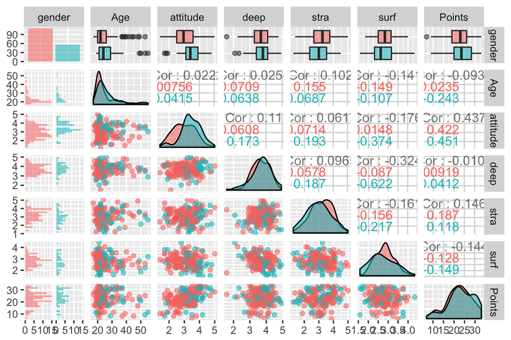

```r
library(GGally) # Loading library for plotting
library(ggplot2) # Loading library for plotting
p <- ggpairs(lrn14, mapping = aes(col = gender, alpha = 0.3), lower = list(combo = wrap("facethist", bins = 20)))
p
```

- This plot shows the distribution of the variables. The colours refer to gender and show the correlation between each of the variables. Surface questions seem to be negatively correlated with all of the variables. Highest correlation is observed between points and attitude. There is difference between females and males overall as suggested by the density plots.
- Fitting a linear regression model

```r
my_model <- lm(Points ~ attitude + stra + surf, data = lrn14)
summary(my_model)
```

```
##
## Call:
## lm(formula = Points ~ attitude + stra + surf, data = lrn14)
##
## Residuals:
##      Min       1Q   Median       3Q      Max
## -17.1550  -3.4346   0.5156   3.6401  10.8952
##
## Coefficients:
##             Estimate Std. Error t value Pr(>|t|)
## (Intercept)  11.0171     3.6837   2.991  0.00322 **
## attitude      3.3952     0.5741   5.913 1.93e-08 ***
## stra          0.8531     0.5416   1.575  0.11716
## surf         -0.5861     0.8014  -0.731  0.46563
## ---
## Signif. codes:  0 '***' 0.001 '**' 0.01 '*' 0.05 '.' 0.1 ' ' 1
##
## Residual standard error: 5.296 on 162 degrees of freedom
## Multiple R-squared:  0.2074, Adjusted R-squared:  0.1927
## F-statistic: 14.13 on 3 and 162 DF,  p-value: 3.156e-08
```

```r
final_model <- lm(Points ~ attitude, data = lrn14)
summary(final_model)
```

```
##
## Call:
## lm(formula = Points ~ attitude, data = lrn14)
##
## Residuals:
##      Min       1Q   Median       3Q      Max
## -16.9763  -3.2119   0.4339   4.1534  10.6645
##
## Coefficients:
##             Estimate Std. Error t value Pr(>|t|)
## (Intercept)  11.6372     1.8303   6.358 1.95e-09 ***
## attitude      3.5255     0.5674   6.214 4.12e-09 ***
## ---
## Signif. codes:  0 '***' 0.001 '**' 0.01 '*' 0.05 '.' 0.1 ' ' 1
##
## Residual standard error: 5.32 on 164 degrees of freedom
## Multiple R-squared:  0.1906, Adjusted R-squared:  0.1856
## F-statistic: 38.61 on 1 and 164 DF,  p-value: 4.119e-09
```

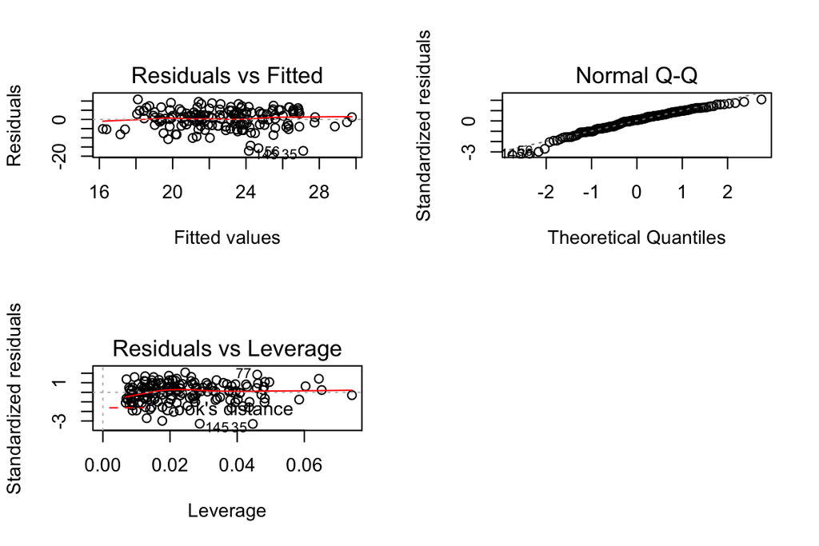

```r
par(mfrow = c(2,2))
plot(my_model, which = 1)
plot(my_model, which = 2)
plot(my_model, which = 5)
```

- In linear regression, we also assume that the residuals have a constant variance. If this assumption is not true, it implies that the size of the error is dependent on independent variables. The first plot is done to test this parameter.
- In linear regression, the most obvious assumption is that the variables are linearly associated with the dependent variable. However, it is also assumed that the errors would be normally distributed. The QQplot shows the normality of the residuals (Predicted value - actual value).
- The leverage plot shows how each of the observations affect the model. It is used to detect outliers. In our case, none of the points seem to be outliers.

# Logistic Regression

*This week’s work has been mainly related to performing logistic regression in R*

> Reading in the file & loading the required libraries

```r
alc <- read.table("~/Documents/GitHub/IODS-project/data/alcohol_consumption.txt", header = T, sep = "\t")
library(tidyr)
library(dplyr)
```

```r
library(ggplot2)
library(gridExtra)
```

> Learning more about the data

```r
colnames(alc)
```

```
##  [1] "school"     "sex"        "age"        "address"    "famsize"
##  [6] "Pstatus"    "Medu"       "Fedu"       "Mjob"       "Fjob"
## [11] "reason"     "nursery"    "internet"   "guardian"   "traveltime"
## [16] "studytime"  "failures"   "schoolsup"  "famsup"     "paid"
## [21] "activities" "higher"     "romantic"   "famrel"     "freetime"
## [26] "goout"      "Dalc"       "Walc"       "health"     "absences"
## [31] "G1"         "G2"         "G3"         "alc_use"    "high_use"
```

```r
dim(alc)
```

```
## [1] 382  35
```

As can be seen above, this file has information about 382 individuals with 35 variables for each student. This data is regarding alcohol consumption and high school performance of two Portugese schools. This data also includes demographic information, student grades, social and school related features. We will perform a **logistic regression** comparing **students drinking high amounts of alcohol** *vs* **students drinking low amounts of alcohol**

> Take a guess
- Just for funsake, trying to guess 4 variables that may be associated with high alcohol usage:
- Freetime: More freetime, more likely are the students likely to drink more
- Absences: Higher absences may be associated with alcohol usage
- Sex: Male gender maybe associated with higher alcohol usage
- G3: Student grades might be an indicator of alcohol consumption. Lower grades may be indicator of higher alcohol usage.

> Exploring the data!
1. Using Barplots

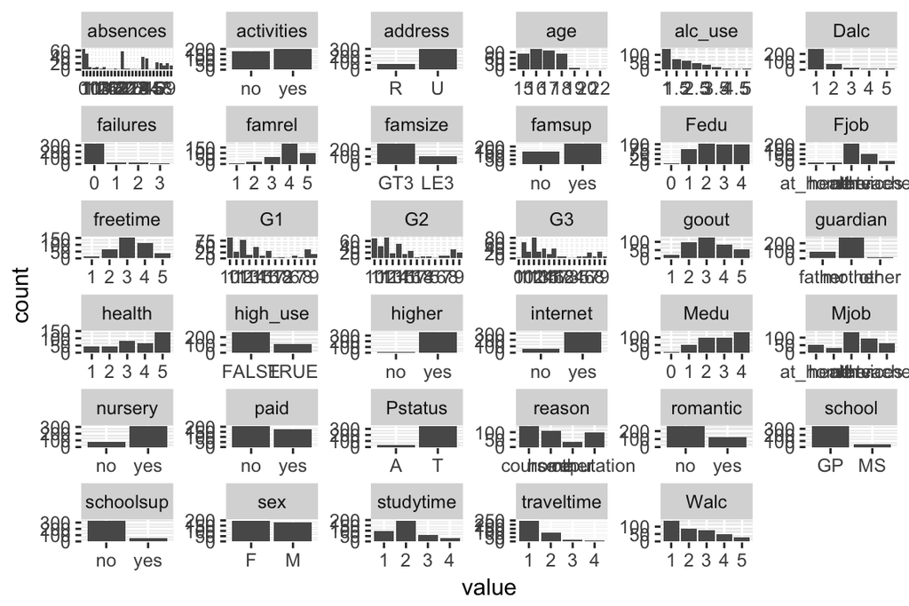

```r
gather(alc) %>% ggplot(aes(value)) + facet_wrap("key", scales = "free") + geom_bar()
```

2. Using cross-tabulations

```r
alc %>% group_by(high_use, sex) %>% summarise(count = n(), mean_grade = mean(G3))
```

```
## # A tibble: 4 x 4
## # Groups:   high_use [?]
##   high_use    sex count mean_grade
##      <lgl> <fctr> <int>      <dbl>
## 1    FALSE      F   156   11.39744
## 2    FALSE      M   112   12.20536
## 3     TRUE      F    42   11.71429
## 4     TRUE      M    72   10.27778
```

3. Using box-plots

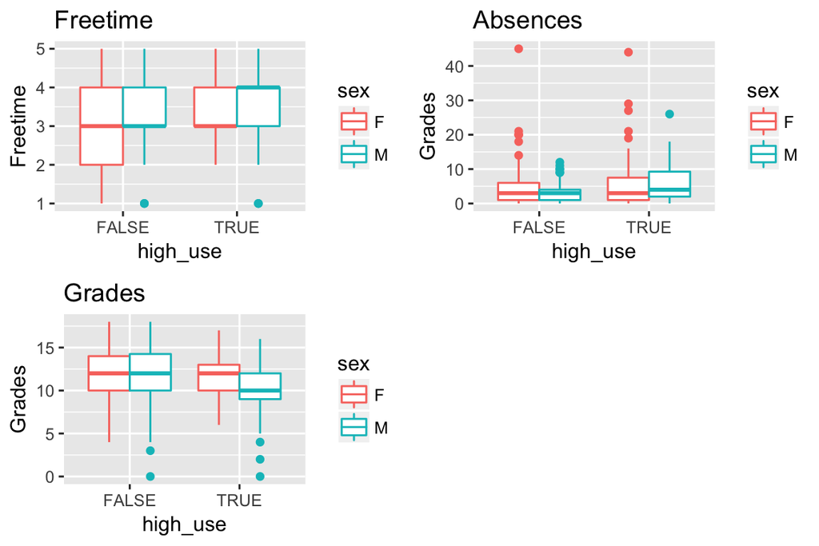

```r
g1 <- ggplot(alc, aes(x = high_use, y = absences, col = sex)) + geom_boxplot() + ylab("Grades") + ggtitle("Absences")
g2 <- ggplot(alc, aes(x = high_use, y = G3, col = sex)) + geom_boxplot() + ylab("Grades") + ggtitle("Grades")
g3 <- ggplot(alc, aes(x = high_use, y = freetime, col = sex)) + geom_boxplot() + ylab("Freetime") + ggtitle("Freetime")
grid.arrange(g3, g1, g2, ncol = 2)
```

Based on the above plots, it seems that all the averages for the variables seem to be much more different in males than in females.

> Performing logistic regression

```r
mod1 <- glm(high_use ~ freetime + absences + G3 + sex, data = alc, family = "binomial")
summary(mod1)
```

```
##
## Call:
## glm(formula = high_use ~ freetime + absences + G3 + sex, family = "binomial",
##     data = alc)
##
## Deviance Residuals:
##     Min       1Q   Median       3Q      Max
## -2.0212  -0.8299  -0.6063   1.0926   2.1162
##
## Coefficients:
##             Estimate Std. Error z value Pr(>|z|)
## (Intercept) -1.87119    0.61712  -3.032 0.002428 **
## freetime     0.28229    0.12544   2.250 0.024423 *
## absences     0.09394    0.02293   4.097 4.18e-05 ***
## G3          -0.07348    0.03610  -2.036 0.041778 *
## sexM         0.88194    0.24645   3.579 0.000346 ***
## ---
## Signif. codes:  0 '***' 0.001 '**' 0.01 '*' 0.05 '.' 0.1 ' ' 1
##
## (Dispersion parameter for binomial family taken to be 1)
##
##     Null deviance: 465.68  on 381  degrees of freedom
## Residual deviance: 420.33  on 377  degrees of freedom
## AIC: 430.33
##
## Number of Fisher Scoring iterations: 4
```

```r
OR <- exp(coef(mod1))
CI <- exp(confint(mod1))
cbind(OR, CI)
```

```
##                    OR      2.5 %    97.5 %
## (Intercept) 0.1539399 0.04471733 0.5058444
## freetime    1.3261680 1.03978990 1.7022310
## absences    1.0984987 1.05237029 1.1515837
## G3          0.9291511 0.86511705 0.9970999
## sexM        2.4155823 1.49749137 3.9428978
```

As can be seen from above, all the speculative variables seem to be associated with high alcohol usage. The largest being for male, where the odds suggest that a male student is 2.42 times more likely to consume high_alcohol as compared to a female student. Freetime and absences also have odds ratio more than 1 indicating they are directly correlated with high alcohol consumption. Grades as expected are inversely correlated with high alcohol consumption.

> Testing the predictive power of the model based on these 4 variables

```r
probabilities <- predict(mod1, type = "response")
alc <- mutate(alc, probability = probabilities)
alc <- mutate(alc, prediction = probability > 0.5)
table(high_use = alc$high_use, prediction = alc$prediction) %>% prop.table()
```

```
##         prediction
## high_use      FALSE       TRUE
##    FALSE 0.66230366 0.03926702
##    TRUE  0.22513089 0.07329843
```

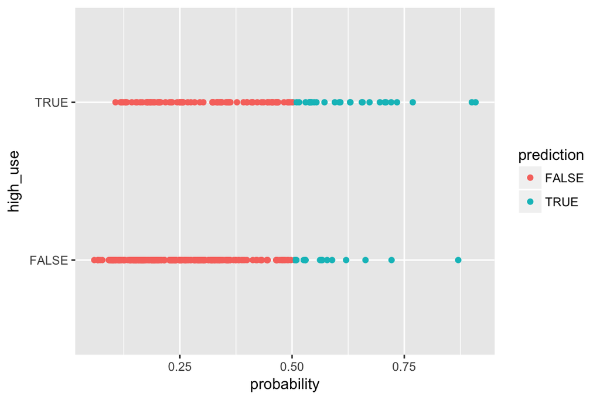

```r
g <- ggplot(alc, aes(x = probability, y = high_use, col = prediction))
g + geom_point()
```

As can be seen from the table and the plot, this model isn’t optimal. The model error is ~25%. Furthermore, there is a high number of false negatives as compared to false positives.

# Clustering and Classification

*This week’s work is related to classifying and clustering data*

> Loading the dataset and the required libraries

```r
library(MASS)
```

```r
library(corrplot)
library(tidyverse)
library(dplyr)
library(ggplot2)
data("Boston")
```

Exploring the structure and dimension of the dataset

```r
str(Boston)
```

```
## 'data.frame':    506 obs. of  14 variables:
##  $ crim   : num  0.00632 0.02731 0.02729 0.03237 0.06905 ...
##  $ zn     : num  18 0 0 0 0 0 12.5 12.5 12.5 12.5 ...
##  $ indus  : num  2.31 7.07 7.07 2.18 2.18 2.18 7.87 7.87 7.87 7.87 ...
##  $ chas   : int  0 0 0 0 0 0 0 0 0 0 ...
##  $ nox    : num  0.538 0.469 0.469 0.458 0.458 0.458 0.524 0.524 0.524 0.524 ...
##  $ rm     : num  6.58 6.42 7.18 7 7.15 ...
##  $ age    : num  65.2 78.9 61.1 45.8 54.2 58.7 66.6 96.1 100 85.9 ...
##  $ dis    : num  4.09 4.97 4.97 6.06 6.06 ...
##  $ rad    : int  1 2 2 3 3 3 5 5 5 5 ...
##  $ tax    : num  296 242 242 222 222 222 311 311 311 311 ...
##  $ ptratio: num  15.3 17.8 17.8 18.7 18.7 18.7 15.2 15.2 15.2 15.2 ...
##  $ black  : num  397 397 393 395 397 ...
##  $ lstat  : num  4.98 9.14 4.03 2.94 5.33 ...
##  $ medv   : num  24 21.6 34.7 33.4 36.2 28.7 22.9 27.1 16.5 18.9 ...
```

```r
dim(Boston)
```

```
## [1] 506  14
```

The Boston dataset contains information about housing in Boston, Mass. It’s a relatively small dataset with only 506 observations and contains 14 variables. Some of these variables include crime rates, proportion of residential land zoned, nitric oxide concentration, average number of rooms per dwelling and so on.

> Graphical overview of the dataset

[figure not shown]

```r
#pairs(Boston)
gather(Boston) %>% ggplot(aes(value)) + facet_wrap("key", scales = "free") + geom_bar()
```

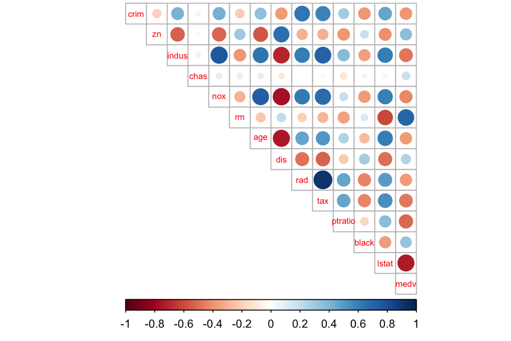

```r
cor_matrix<-cor(Boston)
corrplot(cor_matrix %>% round(2), method="circle", type = "upper", cl.pos = "b", tl.pos = "d", tl.cex = 0.6)
```

As can be seen above, the variables follow different kinds of distributions. We have also calculated the correlations between these distributions. The highest correlation is between the variables “rad” and “tax” where rad stands for accessibility to radial highways. There also seems to be a high negative correlation between proportion of owner occupied units built prior to 1940 and weighted distance to one of the 5 working centres in Boston represented by variables “age” and “dis”.

> Standardizing the dataset

```r
boston_scaled <- scale(Boston)
summary(boston_scaled)
```

```
##       crim                 zn               indus
##  Min.   :-0.419367   Min.   :-0.48724   Min.   :-1.5563
##  1st Qu.:-0.410563   1st Qu.:-0.48724   1st Qu.:-0.8668
##  Median :-0.390280   Median :-0.48724   Median :-0.2109
##  Mean   : 0.000000   Mean   : 0.00000   Mean   : 0.0000
##  3rd Qu.: 0.007389   3rd Qu.: 0.04872   3rd Qu.: 1.0150
##  Max.   : 9.924110   Max.   : 3.80047   Max.   : 2.4202
##       chas              nox                rm               age
##  Min.   :-0.2723   Min.   :-1.4644   Min.   :-3.8764   Min.   :-2.3331
##  1st Qu.:-0.2723   1st Qu.:-0.9121   1st Qu.:-0.5681   1st Qu.:-0.8366
##  Median :-0.2723   Median :-0.1441   Median :-0.1084   Median : 0.3171
##  Mean   : 0.0000   Mean   : 0.0000   Mean   : 0.0000   Mean   : 0.0000
##  3rd Qu.:-0.2723   3rd Qu.: 0.5981   3rd Qu.: 0.4823   3rd Qu.: 0.9059
##  Max.   : 3.6648   Max.   : 2.7296   Max.   : 3.5515   Max.   : 1.1164
##       dis               rad               tax             ptratio
##  Min.   :-1.2658   Min.   :-0.9819   Min.   :-1.3127   Min.   :-2.7047
##  1st Qu.:-0.8049   1st Qu.:-0.6373   1st Qu.:-0.7668   1st Qu.:-0.4876
##  Median :-0.2790   Median :-0.5225   Median :-0.4642   Median : 0.2746
##  Mean   : 0.0000   Mean   : 0.0000   Mean   : 0.0000   Mean   : 0.0000
##  3rd Qu.: 0.6617   3rd Qu.: 1.6596   3rd Qu.: 1.5294   3rd Qu.: 0.8058
##  Max.   : 3.9566   Max.   : 1.6596   Max.   : 1.7964   Max.   : 1.6372
##      black             lstat              medv
##  Min.   :-3.9033   Min.   :-1.5296   Min.   :-1.9063
##  1st Qu.: 0.2049   1st Qu.:-0.7986   1st Qu.:-0.5989
##  Median : 0.3808   Median :-0.1811   Median :-0.1449
##  Mean   : 0.0000   Mean   : 0.0000   Mean   : 0.0000
##  3rd Qu.: 0.4332   3rd Qu.: 0.6024   3rd Qu.: 0.2683
##  Max.   : 0.4406   Max.   : 3.5453   Max.   : 2.9865
```

```r
boston_scaled <- as.data.frame(boston_scaled)
bins <- quantile(boston_scaled$crim)
crime <- cut(boston_scaled$crim, breaks = bins, include.lowest = TRUE, labels = c("low", "med_low", "med_high", "high"))
boston_scaled <- dplyr::select(boston_scaled, -crim)
boston_scaled <- data.frame(boston_scaled, crime)
ind <- sample(nrow(boston_scaled),  size = nrow(boston_scaled) * 0.8)
train <- boston_scaled[ind,]
test <- boston_scaled[-ind,]
```

Scaling helps in normalizing the continuous variables. This basically means that we subtract mean from all the values and divide by the standard deviation of that variable. Furthermore, we have created a categorical variable for crime using the quantiles as break points. We have further divided the dataset into training (80%) and test sets (20%).

> Creating Linear Discriminant Analysis model

```r
lda.fit <- lda(crime ~ ., data = train)
lda.fit
```

```
## Call:
## lda(crime ~ ., data = train)
##
## Prior probabilities of groups:
##       low   med_low  med_high      high
## 0.2376238 0.2549505 0.2648515 0.2425743
##
## Group means:
##                  zn      indus         chas        nox         rm
## low       1.0096632 -0.8897148 -0.108283225 -0.9028761  0.4039673
## med_low  -0.1265311 -0.3111139 -0.042983423 -0.5908215 -0.1479260
## med_high -0.3734355  0.1378702  0.279600872  0.3088681  0.1644602
## high     -0.4872402  1.0171960  0.008892378  1.0757195 -0.4142845
##                 age        dis        rad        tax     ptratio
## low      -0.9256926  0.9361717 -0.6911655 -0.7262722 -0.41057242
## med_low  -0.3699178  0.4112157 -0.5525898 -0.5006202 -0.03417185
## med_high  0.3956222 -0.3487077 -0.4097844 -0.3275784 -0.23070272
## high      0.8432790 -0.8680759  1.6373367  1.5134896  0.77985517
##                black        lstat        medv
## low       0.37646365 -0.775465463  0.48197983
## med_low   0.31980709 -0.117433132 -0.01042862
## med_high  0.09168286 -0.004708542  0.21094584
## high     -0.68990571  0.892666981 -0.65406016
##
## Coefficients of linear discriminants:
##                 LD1         LD2         LD3
## zn       0.04807819  0.81766323 -1.03952466
## indus    0.01056878 -0.18011510  0.19569468
## chas    -0.08138868 -0.06962263  0.02784229
## nox      0.48352493 -0.71969641 -1.22508893
## rm      -0.10392865 -0.12344173 -0.20255192
## age      0.26023305 -0.37434342 -0.14202734
## dis     -0.04645623 -0.34079250  0.35476476
## rad      3.19120342  0.90683816  0.09941105
## tax     -0.07132755  0.08028827  0.48921044
## ptratio  0.14378172 -0.04095391 -0.28217514
## black   -0.13177063  0.04647070  0.11417099
## lstat    0.21848130 -0.30763052  0.36559632
## medv     0.20941137 -0.45157071 -0.10759540
##
## Proportion of trace:
##    LD1    LD2    LD3
## 0.9451 0.0413 0.0137
```

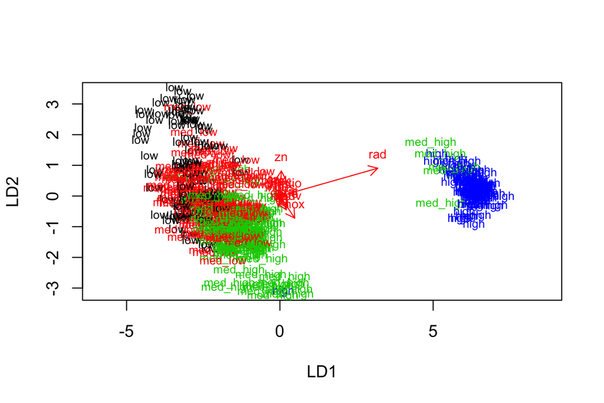

```r
lda.arrows <- function(x, myscale = 1, arrow_heads = 0.1, color = "red", tex = 0.75, choices = c(1,2)){
  heads <- coef(x)
  arrows(x0 = 0, y0 = 0,
         x1 = myscale * heads[,choices[1]],
         y1 = myscale * heads[,choices[2]], col=color, length = arrow_heads)
  text(myscale * heads[,choices], labels = row.names(heads),
       cex = tex, col=color, pos=3)
}
classes <- as.numeric(train$crime)
plot(lda.fit, dimen = 2, col = classes, pch = classes)
lda.arrows(lda.fit, myscale = 1)
```

> Predicting on the test data

```r
correct_classes <- test$crime
test <- dplyr::select(test, -crime)
lda.pred <- predict(lda.fit, newdata = test)
table(correct = correct_classes, predicted = lda.pred$class)
```

```
##           predicted
## correct    low med_low med_high high
##   low       14      13        4    0
##   med_low    7       8        8    0
##   med_high   0       3       15    1
##   high       0       0        0   29
```

> Clustering the data

```r
library(MASS)
data("Boston")
boston_scaled <- scale(Boston)
boston_scaled <- as.data.frame(boston_scaled)
dist_eu <- dist(boston_scaled, method = "euclidean")
summary(dist_eu)
```

```
##    Min. 1st Qu.  Median    Mean 3rd Qu.    Max.
##  0.1343  3.4625  4.8241  4.9111  6.1863 14.3970
```

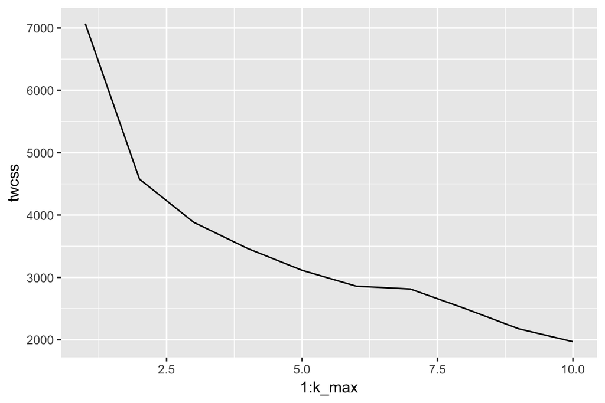

```r
k_max <- 10
twcss <- sapply(1:k_max, function(k){kmeans(boston_scaled, k)$tot.withinss})
qplot(x = 1:k_max, y = twcss, geom = 'line')
```

[figure not shown]

```r
km <-kmeans(boston_scaled, centers = 2)
pairs(boston_scaled, col = km$cluster)
```

So we tried clustering the Boston dataset. We started off with not knowing what the ideal number of clusters would be. We first calculate the euclidean distances. We then create different models with 1 - 10 clusters. As can be seen from the plot, the total within sum of squares sees the biggest drop between 1 and 2 hence it seems that the ideal number of cluster for this dataset is 2. Based on the last plot, we see that some variables along with their interactions are very good at clustering such as the variable crime, whereas others aren’t such as lstat.